# Biostat 212a Homework 6

Due Mar 22, 2025 @ 11:59PM

Author

Nathaniel Boyle and 006525153

Published

March 21, 2025

Load R libraries.

```r
if (!requireNamespace("pheatmap", quietly = TRUE)) {
  install.packages("pheatmap", repos = "https://cloud.r-project.org/")
}
if (!requireNamespace("ggdendro", quietly = TRUE)) {
  install.packages("ggdendro", repos = "https://cloud.r-project.org/")
}
if (!requireNamespace("tidyclust", quietly = TRUE)) {
  install.packages("tidyclust", repos = "https://cloud.r-project.org/")
}
if (!requireNamespace("RcppHungarian", quietly = TRUE)) {
  install.packages("RcppHungarian", repos = "https://cloud.r-project.org/")
}
if (!requireNamespace("glmnet", quietly = TRUE)) {
  install.packages("glmnet", repos = "https://cloud.r-project.org/")
}
if (!requireNamespace("dplyr", quietly = TRUE)) {
  install.packages("dplyr", repos = "https://cloud.r-project.org/")
}
if (!requireNamespace("FactoMineR", quietly = TRUE)) {
  install.packages("FactoMineR", repos = "https://cloud.r-project.org/")
}
if (!requireNamespace("factoextra", quietly = TRUE)) {
  install.packages("factoextra", repos = "https://cloud.r-project.org/")
}
# Core libraries for data manipulation and visualization
library(tidyverse)  # for data manipulation and visualization
library(tidymodels) # A framework for building machine learning models
library(readr)      # Functions for reading and writing data
library(ggplot2)    # for creating visualizations
library(ggdendro)   # visualize hierarchical clustering results using dendrograms

# Machine learning and statistical modeling libraries
library(glmnet)     # Implements LASSO and Ridge regression
library(yardstick)  # evaluating machine learning models
library(workflows)  # Facilitates building and managing workflows for machine learning tasks
library(parsnip)    # Part of `tidymodels` for specifying and fitting models
library(randomForest) # Implements the random forest algorithm
library(xgboost)    # Implements the gradient boosting machine (GBM) algorithm
library(caret)      # for training and evaluating machine learning models

# Time series and clustering libraries
library(tswge)      # For time series analysis
library(tidyclust)  # Provides tools for clustering tasks
library(RcppHungarian) # Implements the Hungarian algorithm for solving problems
library(dplyr)      # For data manipulation,

# Data transformation and visualization utilities
library(reshape2)   # Provides functions for reshaping data (e.g., melting and casting)
library(gridExtra)  # Facilitates arranging multiple plots in a grid layout
library(pheatmap)   # For creating heatmaps with advanced customization options

# Dimensionality reduction and visualization libraries
library(umap)       # Implements the UMAP
library(FactoMineR) # A package for multivariate data analysis (e.g., PCA)
library(factoextra) # Functions for visualizing the results of PCA
```

## 1 New York Stock Exchange (NYSE) data (1962-1986) (140 pts)

The [`NYSE.csv`](https://raw.githubusercontent.com/ucla-biostat-212a/2025winter/master/slides/data/NYSE.csv) file contains three daily time series from the New York Stock Exchange (NYSE) for the period Dec 3, 1962-Dec 31, 1986 (6,051 trading days).

- `Log trading volume` ($v_t$): This is the fraction of all outstanding shares that are traded on that day, relative to a 100-day moving average of past turnover, on the log scale.
- `Dow Jones return` ($r_t$): This is the difference between the log of the Dow Jones Industrial Index on consecutive trading days.
- `Log volatility` ($z_t$): This is based on the absolute values of daily price movements.

```r
# Read in NYSE data from url

url = "https://raw.githubusercontent.com/ucla-biostat-212a/2025winter/master/slides/data/NYSE.csv"
NYSE <- read_csv(url)

NYSE
```

```
# A tibble: 6,051 × 6
   date       day_of_week DJ_return log_volume log_volatility train
   <date>     <chr>           <dbl>      <dbl>          <dbl> <lgl>
 1 1962-12-03 mon         -0.00446     0.0326           -13.1 TRUE
 2 1962-12-04 tues         0.00781     0.346            -11.7 TRUE
 3 1962-12-05 wed          0.00384     0.525            -11.7 TRUE
 4 1962-12-06 thur        -0.00346     0.210            -11.6 TRUE
 5 1962-12-07 fri          0.000568    0.0442           -11.7 TRUE
 6 1962-12-10 mon         -0.0108      0.133            -10.9 TRUE
 7 1962-12-11 tues         0.000124   -0.0115           -11.0 TRUE
 8 1962-12-12 wed          0.00336     0.00161          -11.0 TRUE
 9 1962-12-13 thur        -0.00330    -0.106            -11.0 TRUE
10 1962-12-14 fri          0.00447    -0.138            -11.0 TRUE
# ℹ 6,041 more rows
```

```r
acfdf <- function(vec) {
  vacf <- acf(vec, plot = F)
  with(vacf, data.frame(lag, acf))
}

ggacf <- function(vec) {
  ac <- acfdf(vec)
  ggplot(data = ac, aes(x=lag, y = acf)) +geom_hline(aes(yintercept = 0)) +
    geom_segment(mapping = aes(xend = lag, yend = 0))
}

tplot <- function(vec) {
  df <- data.frame(X = vec, t = seq_along(vec))
  ggplot(data = df, aes(x = t, y = X)) +geom_line()
}
```

The **autocorrelation** at lag $\ell$ is the correlation of all pairs $(v_t, v_{t-\ell})$ that are $\ell$ trading days apart. These sizable correlations give us confidence that past values will be helpful in predicting the future.

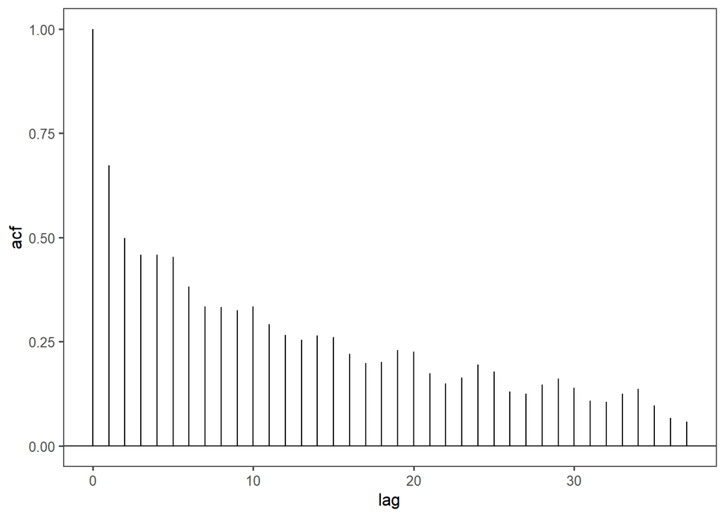

Figure 1: The autocorrelation function for log volume. We see that nearby values are fairly strongly correlated, with correlations above 0.2 as far as 20 days apart.

```r
ggacf(NYSE$log_volume) + ggthemes::theme_few()
```

Do a similar plot for (1) the correlation between $v_t$ and lag $\ell$ `Dow Jones return` $r_{t-\ell}$ and (2) correlation between $v_t$ and lag $\ell$ `Log volatility` $z_{t-\ell}$.

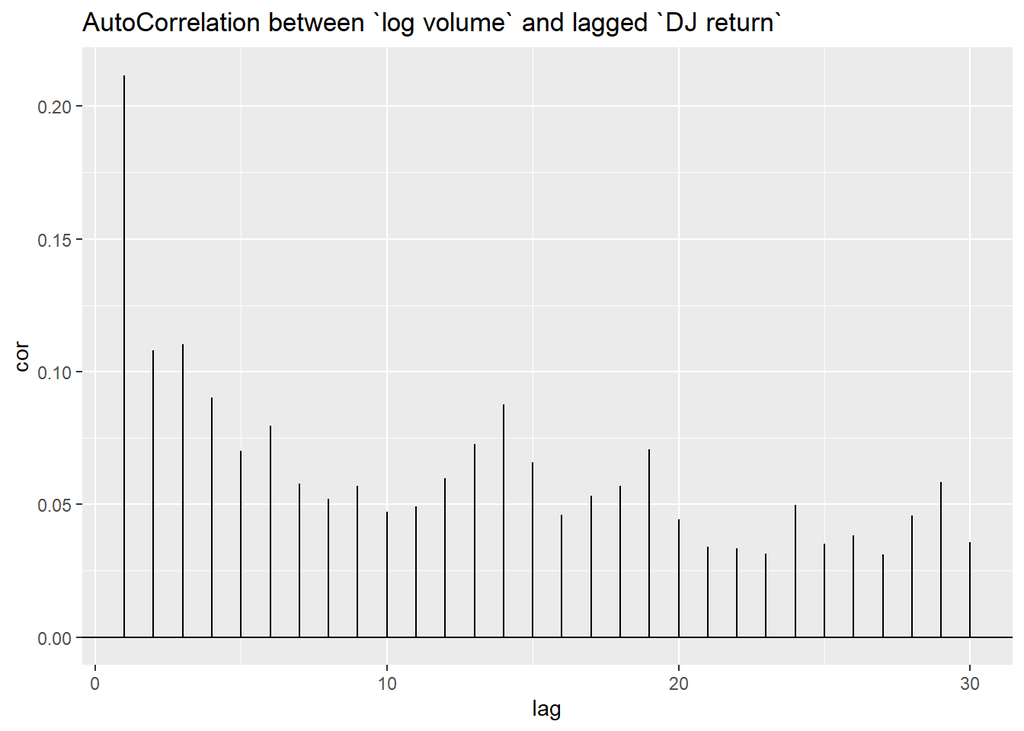

```r
seq(1, 30) %>%
  map(function(x) {cor(NYSE$log_volume , lag(NYSE$DJ_return, x),
                       use = "pairwise.complete.obs")}) %>%
  unlist() %>%
  tibble(lag = 1:30, cor = .) %>%
  ggplot(aes(x = lag, y = cor)) +
  geom_hline(aes(yintercept = 0)) +
  geom_segment(mapping = aes(xend = lag, yend = 0)) +
  ggtitle("AutoCorrelation between `log volume` and lagged `DJ return`")
```

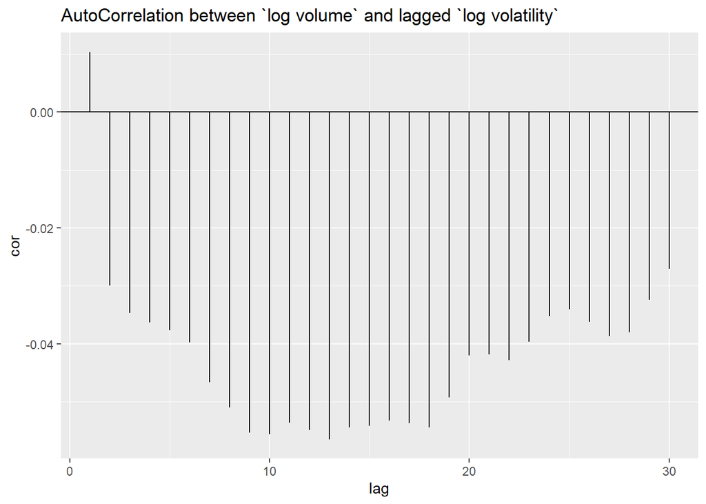

```r
seq(1, 30) %>%
  map(function(x) {cor(NYSE$log_volume , lag(NYSE$log_volatility, x),
                       use = "pairwise.complete.obs")}) %>%
  unlist() %>%
  tibble(lag = 1:30, cor = .) %>%
  ggplot(aes(x = lag, y = cor)) +
  geom_hline(aes(yintercept = 0)) +
  geom_segment(mapping = aes(xend = lag, yend = 0)) +
  ggtitle("AutoCorrelation between `log volume` and lagged `log volatility`")
```

### 1.1 Project goal

Our goal is to forecast daily `Log trading volume`, using various machine learning algorithms we learnt in this class.

The data set is already split into train (before Jan 1st, 1980, $n_{\text{train}} = 4,281$) and test (after Jan 1st, 1980, $n_{\text{test}} = 1,770$) sets.

In general, we will tune the lag $L$ to achieve best forecasting performance. In this project, we would fix $L=5$. That is we always use the previous five trading days’ data to forecast today’s `log trading volume`.

Pay attention to the nuance of splitting time series data for cross validation. Study and use the [`time-series`](https://www.tidymodels.org/learn/models/time-series/) functionality in tidymodels. Make sure to use the same splits when tuning different machine learning algorithms.

Use the $R^2$ between forecast and actual values as the cross validation and test evaluation criterion.

### 1.2 Baseline method (20 pts)

We use the straw man (use yesterday’s value of `log trading volume` to predict that of today) as the baseline method. Evaluate the $R^2$ of this method on the test data.

```r
#baseline method

# Create the baseline prediction (using the previous day's log trading volume)
NYSE_baseline <- NYSE |>
  mutate(BaselinePrediction = lag(log_volume, n = 1)) |>
  filter(!is.na(BaselinePrediction))

# View the first few rows to check the baseline predictions
head(NYSE_baseline)
```

```
# A tibble: 6 × 7
  date       day_of_week DJ_return log_volume log_volatility train
  <date>     <chr>           <dbl>      <dbl>          <dbl> <lgl>
1 1962-12-04 tues         0.00781      0.346           -11.7 TRUE
2 1962-12-05 wed          0.00384      0.525           -11.7 TRUE
3 1962-12-06 thur        -0.00346      0.210           -11.6 TRUE
4 1962-12-07 fri          0.000568     0.0442          -11.7 TRUE
5 1962-12-10 mon         -0.0108       0.133           -10.9 TRUE
6 1962-12-11 tues         0.000124    -0.0115          -11.0 TRUE
# ℹ 1 more variable: BaselinePrediction <dbl>
```

```r
# Check the structure of the data to ensure that the Date column is correctly parsed
str(NYSE_baseline)
```

```
tibble [6,050 × 7] (S3: tbl_df/tbl/data.frame)
 $ date              : Date[1:6050], format: "1962-12-04" "1962-12-05" ...
 $ day_of_week       : chr [1:6050] "tues" "wed" "thur" "fri" ...
 $ DJ_return         : num [1:6050] 0.007813 0.003845 -0.003462 0.000568 -0.010824 ...
 $ log_volume        : num [1:6050] 0.3462 0.5253 0.2102 0.0442 0.1332 ...
 $ log_volatility    : num [1:6050] -11.7 -11.7 -11.6 -11.7 -10.9 ...
 $ train             : logi [1:6050] TRUE TRUE TRUE TRUE TRUE TRUE ...
 $ BaselinePrediction: num [1:6050] 0.0326 0.3462 0.5253 0.2102 0.0442 ...
```

```r
head(NYSE_baseline)
```

```
# A tibble: 6 × 7
  date       day_of_week DJ_return log_volume log_volatility train
  <date>     <chr>           <dbl>      <dbl>          <dbl> <lgl>
1 1962-12-04 tues         0.00781      0.346           -11.7 TRUE
2 1962-12-05 wed          0.00384      0.525           -11.7 TRUE
3 1962-12-06 thur        -0.00346      0.210           -11.6 TRUE
4 1962-12-07 fri          0.000568     0.0442          -11.7 TRUE
5 1962-12-10 mon         -0.0108       0.133           -10.9 TRUE
6 1962-12-11 tues         0.000124    -0.0115          -11.0 TRUE
# ℹ 1 more variable: BaselinePrediction <dbl>
```

```r
# Convert 'Date' column to Date type (if not already)
NYSE_baseline$Date <- as.Date(NYSE_baseline$date, format = "%m/%d/%Y")

# Ensure that the 'log_volume' column exists and is named correctly
head(NYSE_baseline)
```

```
# A tibble: 6 × 8
  date       day_of_week DJ_return log_volume log_volatility train
  <date>     <chr>           <dbl>      <dbl>          <dbl> <lgl>
1 1962-12-04 tues         0.00781      0.346           -11.7 TRUE
2 1962-12-05 wed          0.00384      0.525           -11.7 TRUE
3 1962-12-06 thur        -0.00346      0.210           -11.6 TRUE
4 1962-12-07 fri          0.000568     0.0442          -11.7 TRUE
5 1962-12-10 mon         -0.0108       0.133           -10.9 TRUE
6 1962-12-11 tues         0.000124    -0.0115          -11.0 TRUE
# ℹ 2 more variables: BaselinePrediction <dbl>, Date <date>
```

```r
# Create the baseline prediction (using the previous day's log trading volume)
NYSE_baseline <- NYSE_baseline |>
  mutate(BaselinePrediction = lag(log_volume, n = 1)) |>
  filter(!is.na(BaselinePrediction))

# View the first few rows to check the baseline predictions
head(NYSE_baseline)
```

```
# A tibble: 6 × 8
  date       day_of_week DJ_return log_volume log_volatility train
  <date>     <chr>           <dbl>      <dbl>          <dbl> <lgl>
1 1962-12-05 wed          0.00384     0.525            -11.7 TRUE
2 1962-12-06 thur        -0.00346     0.210            -11.6 TRUE
3 1962-12-07 fri          0.000568    0.0442           -11.7 TRUE
4 1962-12-10 mon         -0.0108      0.133            -10.9 TRUE
5 1962-12-11 tues         0.000124   -0.0115           -11.0 TRUE
6 1962-12-12 wed          0.00336     0.00161          -11.0 TRUE
# ℹ 2 more variables: BaselinePrediction <dbl>, Date <date>
```

```r
# Split the data into training and test sets (before and after January 1st, 1980)
train_data <- NYSE_baseline %>%
  filter(Date < "1980-01-01")

test_data <- NYSE_baseline %>%
  filter(Date >= "1980-01-01")

# View the train and test set sizes to ensure proper split
dim(train_data)
```

```
[1] 4279    8
```

```r
dim(test_data)
```

```
[1] 1770    8
```

```r
# Calculate the R^2 for the baseline model on the test data
# Use lm (linear model) to calculate R^2 between predicted and actual log trading volume
model <- lm(log_volume ~ BaselinePrediction, data = test_data)

# Get the R^2 value
summary(model)$r.squared
```

```
[1] 0.348125
```

The test R^2 value of this baseline model is 0.35.

### 1.3 Autoregression (AR) forecaster (30 pts)

- Let
  $$y = \begin{pmatrix} v_{L+1} \\ v_{L+2} \\ v_{L+3} \\ \vdots \\ v_T \end{pmatrix}, \quad M = \begin{pmatrix}
  1 & v_L & v_{L-1} & \cdots & v_1 \\
  1 & v_{L+1} & v_{L} & \cdots & v_2 \\
  \vdots & \vdots & \vdots & \ddots & \vdots \\
  1 & v_{T-1} & v_{T-2} & \cdots & v_{T-L}
  \end{pmatrix}.$$
- Fit an ordinary least squares (OLS) regression of $y$ on $M$, giving
  $$\hat v_t = \hat \beta_0 + \hat \beta_1 v_{t-1} + \hat \beta_2 v_{t-2} + \cdots + \hat \beta_L v_{t-L},$$
  known as an **order-$L$ autoregression** model or **AR($L$)**.

```r
# Example time series data
log_volume <- NYSE$log_volume

# Define the order of the autoregression (L=3 for AR(3) model)
L <- 3

# Create the matrix M with lagged values (first column is for the intercept term)
T <- length(log_volume)
M <- cbind(
  1,  # intercept term (constant)
  lag(log_volume, 1)[(L+1):T],  # lag 1
  lag(log_volume, 2)[(L+1):T],  # lag 2
  lag(log_volume, 3)[(L+1):T]   # lag 3
)

# Create the vector y (the target variable, which is log_volume from L+1 to T)
y <- log_volume[(L+1):T]

# Fit the OLS model using the lm() function (exclude intercept in the formula
# since it's already included in M)
model <- lm(y ~ M - 1)  # '-1' removes the intercept term (since it's already in M)

# View the model coefficients
summary(model)
```

```
Call:
lm(formula = y ~ M - 1)

Residuals:
     Min       1Q   Median       3Q      Max
-1.23068 -0.10214 -0.00333  0.10026  1.03631

Coefficients:
    Estimate Std. Error t value Pr(>|t|)
M1 -0.002227   0.002181  -1.021   0.3073
M2  0.602692   0.012659  47.609   <2e-16 ***
M3 -0.025663   0.014841  -1.729   0.0838 .
M4  0.175733   0.012659  13.883   <2e-16 ***
---
Signif. codes:  0 '***' 0.001 '**' 0.01 '*' 0.05 '.' 0.1 ' ' 1

Residual standard error: 0.1695 on 6044 degrees of freedom
Multiple R-squared:  0.4744,    Adjusted R-squared:  0.474
F-statistic:  1364 on 4 and 6044 DF,  p-value: < 2.2e-16
```

R^2 multiple is 0.47. Adjusted R^2 is 0.47.

- Tune AR(5) with elastic net (lasso + ridge) regularization using all 3 features on the training data, and evaluate the test performance.

```r
# Convert Date column to Date type if it's not already
NYSE$date <- as.Date(NYSE$date, format = "%m/%d/%Y")

# Create lagged features for log_volume, DJIA_return, and log_volatility
L <- 5  # We will use AR(5) model, so L = 5

NYSE_lagged <- NYSE %>%
  mutate(
    lag_log_volume_1 = lag(log_volume, 1),
    lag_log_volume_2 = lag(log_volume, 2),
    lag_log_volume_3 = lag(log_volume, 3),
    lag_log_volume_4 = lag(log_volume, 4),
    lag_log_volume_5 = lag(log_volume, 5),

    lag_DJ_return_1 = lag(DJ_return, 1),
    lag_DJ_return_2 = lag(DJ_return, 2),
    lag_DJ_return_3 = lag(DJ_return, 3),
    lag_DJ_return_4 = lag(DJ_return, 4),
    lag_DJ_return_5 = lag(DJ_return, 5),

    lag_log_volatility_1 = lag(log_volatility, 1),
    lag_log_volatility_2 = lag(log_volatility, 2),
    lag_log_volatility_3 = lag(log_volatility, 3),
    lag_log_volatility_4 = lag(log_volatility, 4),
    lag_log_volatility_5 = lag(log_volatility, 5)
  ) %>%
  filter(complete.cases(.))  # Remove rows with NA values caused by lagging

# Split data into training (before 1980) and test (after 1980)
train_data <- NYSE_lagged %>% filter(date < "1980-01-01")
test_data <- NYSE_lagged %>% filter(date >= "1980-01-01")

# Inspect the sizes of the train and test sets
dim(train_data)
```

```
[1] 4276   21
```

```r
dim(test_data)
```

```
[1] 1770   21
```

```r
# Prepare training data
X_train <- as.matrix(train_data %>% select(starts_with("lag_")))  # All lagged features
y_train <- train_data$log_volume  # Target variable

# Prepare test data
X_test <- as.matrix(test_data %>% select(starts_with("lag_")))
y_test <- test_data$log_volume


# Fit the Elastic Net model using cross-validation
cv_model <- cv.glmnet(X_train, y_train, alpha = 0.5, nfolds = 10)  # alpha = 0.5 for Elastic Net

# View the cross-validation results
cv_model
```

```
Call:  cv.glmnet(x = X_train, y = y_train, nfolds = 10, alpha = 0.5)

Measure: Mean-Squared Error

      Lambda Index Measure        SE Nonzero
min 0.000132    85 0.02306 0.0006780      15
1se 0.003434    50 0.02371 0.0006806      11
```

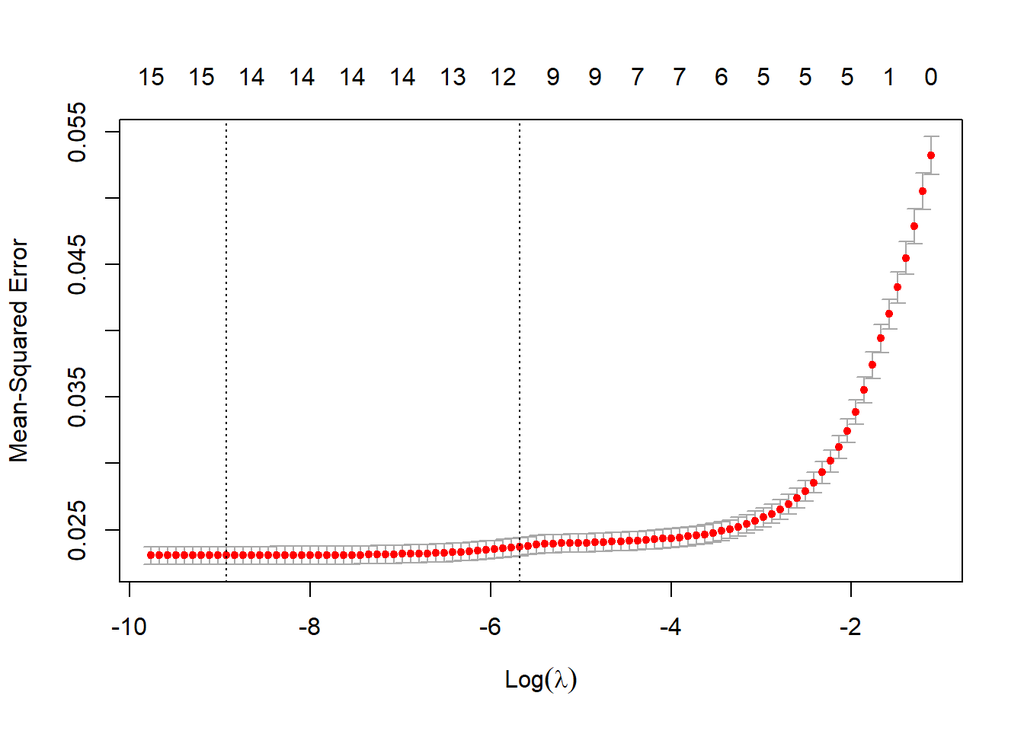

```r
# Plot the cross-validation curve
plot(cv_model)
```

```r
# Extract the cross-validation R-squared values
cv_r_squared <- 1 - cv_model$cvm / mean((y_train - mean(y_train))^2)

# Print the max cv R-squared value
print(max(cv_r_squared))
```

```
[1] 0.5672823
```

```r
# Predict on the test set
y_pred <- predict(cv_model, X_test, s = "lambda.min")

# Calculate R^2 on the test set
rss <- sum((y_test - y_pred)^2)
tss <- sum((y_test - mean(y_test))^2)
r_squared <- 1 - (rss / tss)

# Print the test R^2 value
r_squared
```

```
[1] 0.4128791
```

- Hint: [Workflow: Lasso](https://ucla-biostat-212a.github.io/2025winter/slides/06-modelselection/workflow_lasso.html) is a good starting point.